# In-class exercise 01: Intro to R and ggplot2

15th Jan 2022 - Intro to R and ggplot

Farah https://sg.linkedin.com/in/farahfoo (SMU Masters in IT business (Fintech and Analytics))https://scis.smu.edu.sg/master-it-business  
2022-02-12

# NOTES FROM LECTURE TODAY

Below is the Data science workflow with Tidyverse from [R for Data Science](https://r4ds.had.co.nz/)

*Import –> Tidy –> transform –> visualise <–> model –> communicate*

- Import (readr, haven, readxl)
- Tidy (tidyr)
- transform (dplyr)
- Visualise (purr, ggplot2)
- Model (broom)
- communicate (knitr, rmarkdown)
- others
  - Dealing with Factors (forcats)
  - Dealing with data.frames (tibble)
  - Dealing with string (stringr)

*use r cheatsheets to get the syntax*

# Pike %>% - super important connector

# Installing and loading required libraries

- Loading multiple packages at one go

```r
packages = c('ggplot2', 'tidyverse', 'ggrepel')

for(p in packages){
  if(!require(p, character.only = T)){
    install.packages(p)
  }
  library(p, character.only = T)
}
```

# Importing data into R

- Data should be same level as the rmarkdown file to use the relative file path below

```r
exam_data <-read_csv("data/Exam_data.csv")
summary(exam_data)
```

```
      ID               CLASS              GENDER
 Length:322         Length:322         Length:322
 Class :character   Class :character   Class :character
 Mode  :character   Mode  :character   Mode  :character



     RACE              ENGLISH          MATHS          SCIENCE
 Length:322         Min.   :21.00   Min.   : 9.00   Min.   :15.00
 Class :character   1st Qu.:59.00   1st Qu.:58.00   1st Qu.:49.25
 Mode  :character   Median :70.00   Median :74.00   Median :65.00
                    Mean   :67.18   Mean   :69.33   Mean   :61.16
                    3rd Qu.:78.00   3rd Qu.:85.00   3rd Qu.:74.75
                    Max.   :96.00   Max.   :99.00   Max.   :96.00
```

- using read.csv instead of read_csv may result in messy column names

# Visualisation using ggplot2 package

- ggplot2 is used for Visual Data exploration purpose
- using R graphics to plot histogram vs using ggplot.

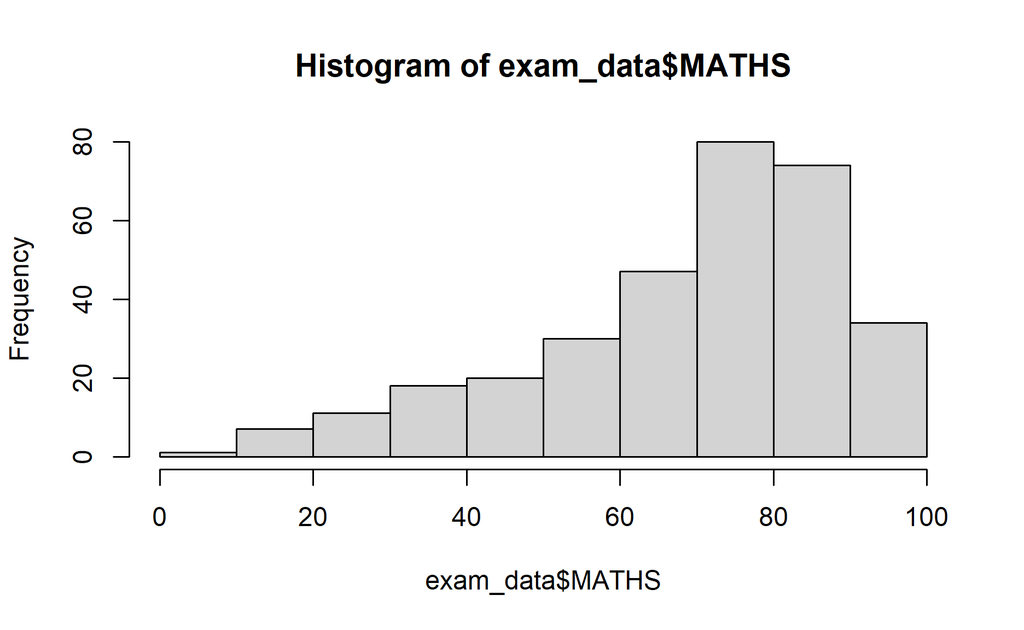

```r
hist(exam_data$MATHS)
```

Note the longer coding but more powerful customisation

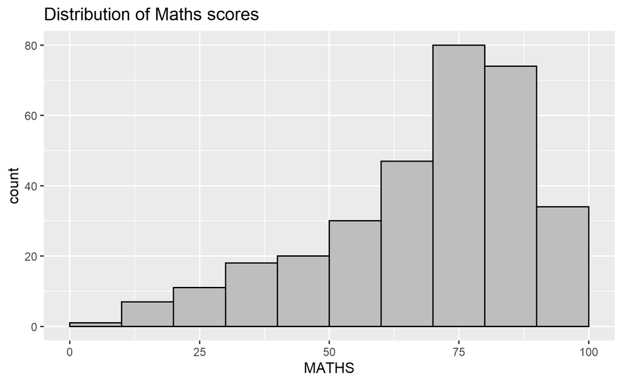

```r
ggplot(data=exam_data,
       aes(x = MATHS)) +
  geom_histogram(bins=10,
                boundary = 100,
                colour = "black",
                  fill="grey") +
        ggtitle("Distribution of Maths scores")
```

## GGPLOT2 elements

- Data
- Aesthetics (aes =df$variablename)
- Geometrics (bar or pie or line or histogram)
- Facets (columns x rows eg. 2 x 5) / grids
- statistics (sum, average etc..)
- Coordinates (x and Y axis)
- Theme (colour/ format of the graph)

Note that the default grom_histogram default bin is 30

### adding theme

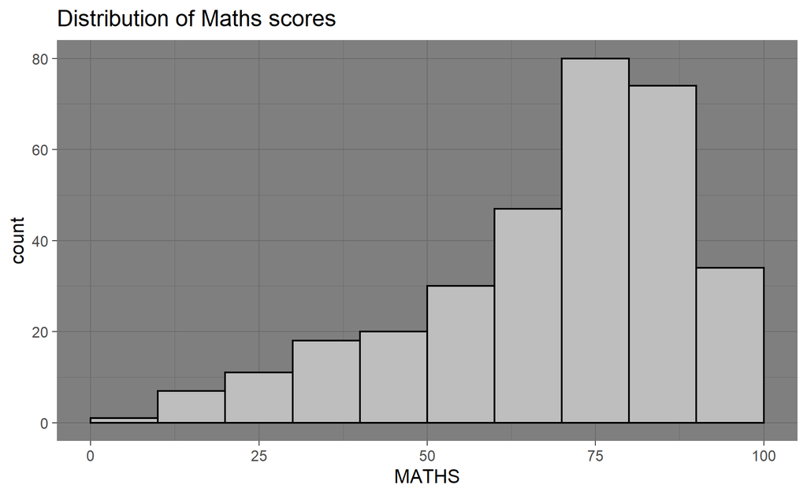

```r
ggplot(data=exam_data,
       aes(x = MATHS)) +
  geom_histogram(bins=10,
                boundary = 100,
                colour = "black",
                  fill="grey") +
        ggtitle("Distribution of Maths scores") +
  theme_dark()
```

### adding facet

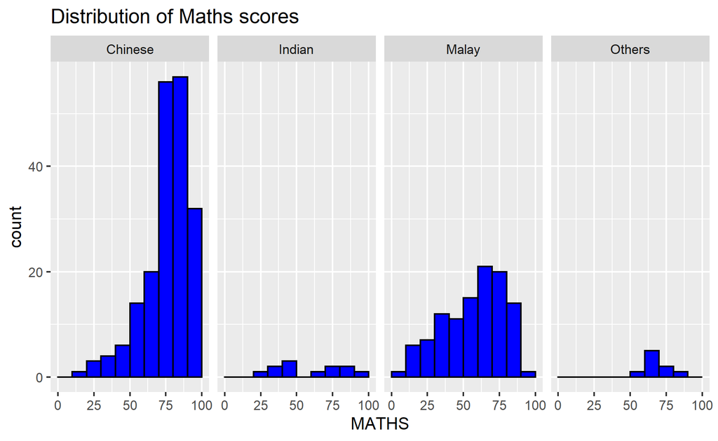

```r
ggplot(data=exam_data,
       aes(x = MATHS)) +
  geom_histogram(bins=10,
                boundary = 100,
                colour = "black",
                  fill="blue") +
        ggtitle("Distribution of Maths scores") +
  facet_grid(cols = vars(RACE))
```

### putting GENDER variable as a fill filter

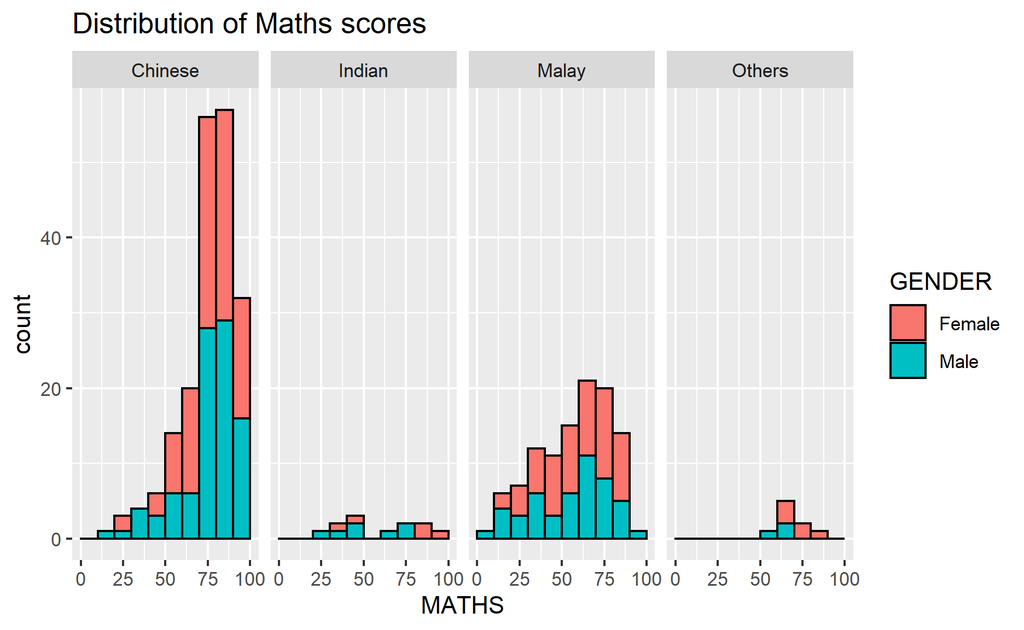

```r
ggplot(data=exam_data,
       aes(x = MATHS,
       fill = GENDER)) +
  geom_histogram(bins=10,
                boundary = 100,
                colour = "black") +
        ggtitle("Distribution of Maths scores") +
  facet_grid(cols = vars(RACE))
```

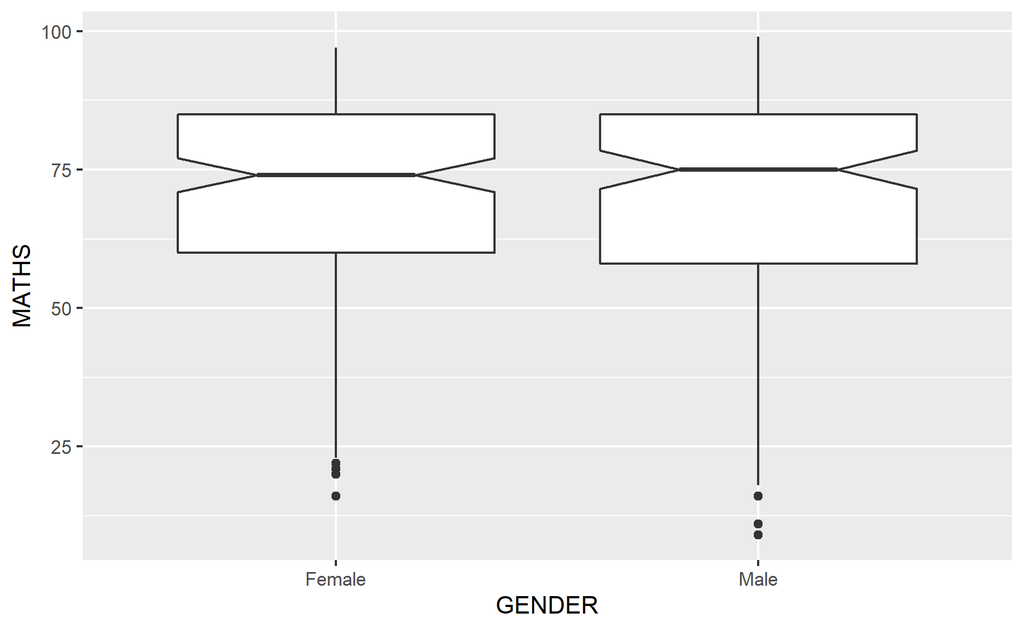

```r
ggplot(data=exam_data,
       aes(y = MATHS,
       x = GENDER)) +
  geom_boxplot(notch = TRUE)
```

### combining boxplot and geompoint together

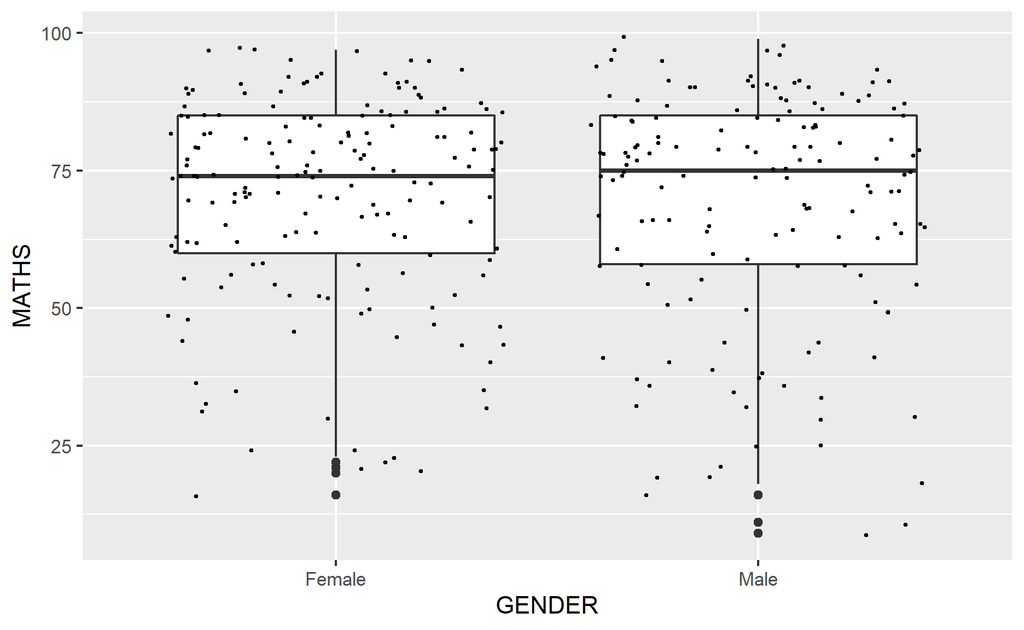

```r
ggplot(data=exam_data,
       aes(y = MATHS,
       x = GENDER)) +
  geom_boxplot() +
  geom_point(position = "jitter",
             size = 0.5)
```

### volin plot is good to compliment boxplot, got error - cannot find dunction geom_volin

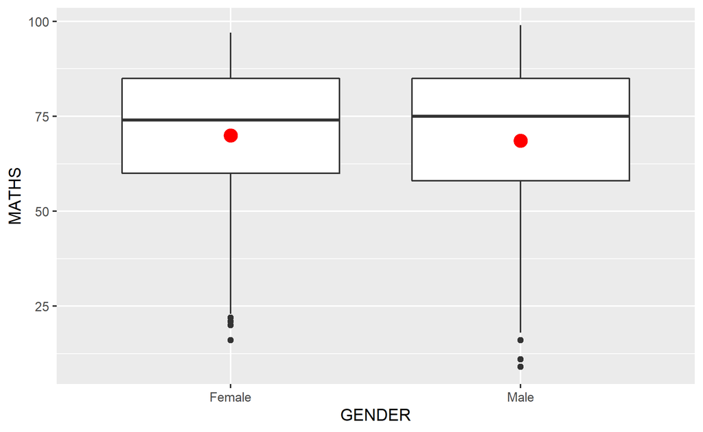

```r
ggplot(data=exam_data,
       aes(y = MATHS, x = GENDER)) +
  geom_boxplot() +
  geom_point (stat = "summary",
              fun.y = "mean",
              colour = "red",
              size = 4)
```

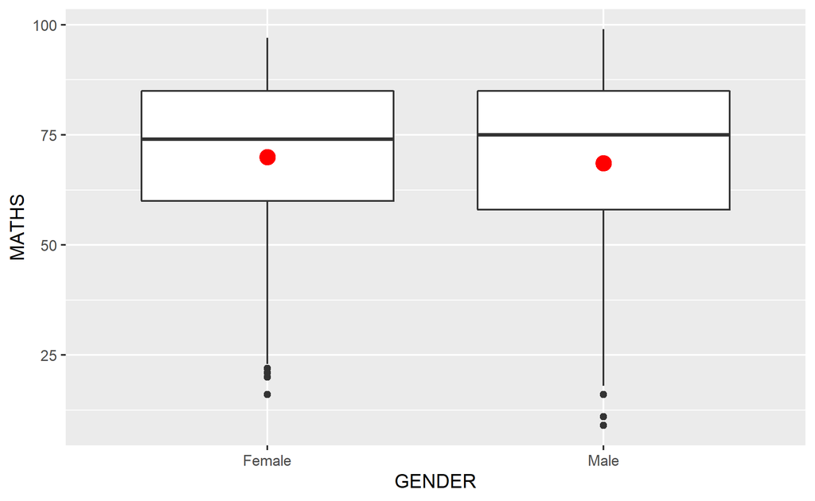

```r
ggplot(data=exam_data,
       aes(y = MATHS, x = GENDER)) +
  geom_boxplot() +
  stat_summary (geom = "point",
                fun.y = "mean",
              colour = "red",
              size = 4)
```